# geo877_project_final

## 1 Libraries

```python
import pandas as pd
# There are multiple problems with installing the geopandas package, the only way we got it to work was with anaconda and "conda install --channel conda-forge geopandas"
# The conda forge installation seems to work best also with other packages that pip has problems with
import geopandas as gpd
from geospatial import *
from pyproj import Transformer
import matplotlib.pyplot as plt
from numpy import *
from PIL import Image, ImageColor
```

## 2 Data Preparation

```python
%%capture

# Reading in flickr data
flickr = pd.read_csv('Flickr_CH_ALL.csv', sep = ';', encoding = 'latin-1', error_bad_lines=False, warn_bad_lines=False)
flickr_filtered = flickr[['lng', 'lat', 'user', 'dateTaken']]

# Reading in border data
border = pd.read_csv('borders_canton.csv')

# Reading in urban areas data
urban = gpd.read_file('urban_union.geojson')

# Simplify Polygon for processing speed further down the line
border_list = []
count = 1
for key, i in border.iterrows():
    count += 1
    if count % 20 == 0:
        border_list.append([i['x'], i['y']])
border_list.append(border_list[0])

# Converting border to a Polygon
border_poly = Polygon(border_list, 0, 1)

# Getting bbox of border
bbox_border = border_poly.bbox

# Converting the crs of borders from epsg:2056 to epsg:4326
transformer = Transformer.from_crs("epsg:2056", "epsg:4326")

# Getting a transformed Bounding Box for roughly filtering flickr data
border_list_4326 = []
for key, i in border.iterrows():
    x = transformer.transform(i['x'], i['y'])
    border_list_4326.append(Point(x[1], x[0]))
bbox_border_4326 = Bbox(border_list_4326)

# Geting a list of urban area polygons
urban_poly_list = []
for mp in urban['geometry']:
    for polygon in mp:
        poly = []
        # Getting the coordinates of polygons
        poly.extend(polygon.exterior.coords[:-1])
        urban_poly_list.append(Polygon(poly, 0, 1))

# Replacing comma to dot in lng and lat becasue there are some commas in these two columns
flickr_filtered['lng'] = list(map(lambda x: float(str(x).replace(',', '.')), flickr_filtered['lng']))
flickr_filtered['lat'] = list(map(lambda x: float(str(x).replace(',', '.')), flickr_filtered['lat']))

# Getting the flickr data in the bbox
flickr_filtered = flickr_filtered[(flickr_filtered['lng']>= bbox_border_4326.ll.x) & (flickr_filtered['lng'] <= bbox_border_4326.ur.x)]
flickr_filtered = flickr_filtered[(flickr_filtered['lat']>= bbox_border_4326.ll.y) & (flickr_filtered['lat'] <= bbox_border_4326.ur.y)]

transformer = Transformer.from_crs("epsg:4326", "epsg:2056")

list_coords = []
for key, i in flickr_filtered.iterrows():
    x = transformer.transform(i['lat'], i['lng'])
    list_coords.append(x)
flickr_filtered['coords'] = list_coords
flickr_filtered['points'] = list(map(lambda i: Point(i[0], i[1]), flickr_filtered['coords']))

# Writing to pickle
pd.to_pickle(flickr_filtered, 'flickr_filtered.pkl')

# Reading pickle for easy further use so that we dont have to filter all the flickr data again, commented out above filtering while working on project
flickr_filtered = pd.read_pickle('flickr_filtered.pkl')
```

```python
print(f'There are {len(flickr_filtered)} flickr entries in our bounding box area.')
```

```
There are 184339 flickr entries in our bounding box area.
```

## 3 Spatial Index of Flickr data

Cell will take 20-30 minutes to run mainly because of the resolution

```python
# Getting spatial index of flickr data
bbox_border_new = Bbox(flickr_filtered['points'])
flickr_filtered_index = PointIndex(flickr_filtered['points'], flickr_filtered['user'], bbox_border_new, 1000)

# Getting the number of contributors per raster
flickr_points_num = flickr_filtered_index.points_num

# Getting centroid coordinates of rasters
raster_coords = flickr_filtered_index.raster_coords

# Rasterizing border
border_raster = borderRaster(raster_coords, 1000, border_poly)

# Removing outside index cells
flickr_points_num = border_raster.remove_outside(flickr_points_num, position=None)
flickr_points_reshaped = flickr_filtered_index.reshapeList(flickr_points_num)
```

## 4 Visualize contributors per cell

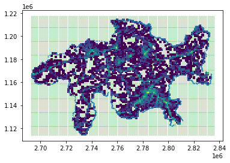

```python
# Coords of ncols*nrows rasters
raster_x = list(map(lambda i: i.x, raster_coords))
raster_y = list(map(lambda i: i.y, raster_coords))

# Border outline
border_poly_x = list(map(lambda i: i.x, border_poly))
border_poly_y = list(map(lambda i: i.y, border_poly))

# Coords of contributors
contri_raster_x = list(map(lambda i: i.x, raster_coords))
contri_raster_y = list(map(lambda i: i.y, raster_coords))

# Because of large differences in contributors: log of data
points_0 = flickr_points_num
for i in range(len(points_0)):
    if points_0[i] == None:
        points_0[i] = 0
with errstate(divide='ignore'):
    points_log = log(points_0)

# Plot Contributors per raster cell
plt.scatter(raster_x, raster_y, s=1, color='green', alpha=0.2)
plt.scatter(contri_raster_x, contri_raster_y, s=10, marker = "s", c = points_log, cmap='viridis')
plt.scatter(border_poly_x, border_poly_y, s=0.5)
plt.show()
```

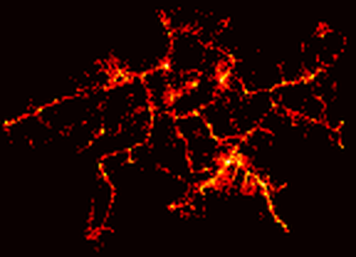

```python
# Improved raster visualisation, pillow package and logarithmised values
def points_to_im(points):

    help_x = list(map(lambda i: i.x, raster_coords))
    count = 0
    for i in range(len(help_x)):
        if help_x[i] == help_x[0] and count != 0:
            break
        else:
            count += 1

    points_0 = points
    for i in range(len(points_0)):
        if points_0[i] == None or points_0[i] == NaN:
            points_0[i] = 0

    with errstate(divide='ignore'):
        points_log = log(points_0)

    for i in range(len(points_log)):
        if points_log[i] == -inf:
            points_log[i] = 0

    points_log *= 255.0/points_log.max()

    points_prepped = []
    for i in points_log:
        if isnan(i):
            points_prepped.append(0)
        else:
            points_prepped.append(int(i))
    points_buckets = ([points_prepped[i:i+int(count)] for i in range(0, len(points_prepped), int(count))])


    points_np = asarray(points_buckets)


    cm = plt.get_cmap('hot')
    colored_image = cm(points_np)
    im = Image.fromarray((colored_image[:,:,:3]*255).astype(uint8))
    basewidth = 500
    wpercent = (basewidth/float(im.size[0]))
    hsize = int((float(im.size[1])*float(wpercent)))
    im = im.resize((basewidth,hsize), Image.LANCZOS)
    im = im.transpose(Image.FLIP_TOP_BOTTOM)


    return points_np, im

display(points_to_im(flickr_points_num)[1])
```

## 5 Morans I calculations

In this section 4 different scenarios will be calculated:

- Morans I before removal of urban areas, 1x1 km grid resolution
- Morans I after removal of urban areas, 1x1 km grid resolution
- Morans I before removal of urban areas, 2x2 km grid resolution
- Morans I after removal of urban areas, 2x2 km grid resolution

# 5.1 Morans I before removal of urban areas, 1x1 km grid resolution

Cell will take 20+ minutes to run because of the local morans i

```
The global Morans I before removal of urban area for 1km resolution is 0.0791
The expected value before removal of urban area for 1km resolution is -0.0003
```

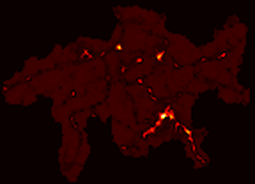

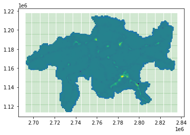

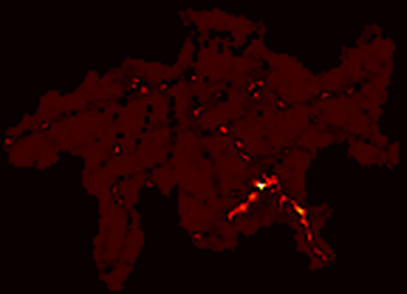

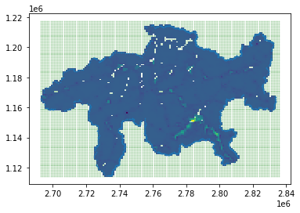

```python
# Global Morans I & Expected Value
morans_prefiltered = MoranI(flickr_points_reshaped)
print(f'The global Morans I before removal of urban area for 1km resolution is {morans_prefiltered.globalMoranI():.4f}')
print(f'The expected value before removal of urban area for 1km resolution is {morans_prefiltered.expectedValue():.4f}')

# Saving values for comparing results in the end
global_1km_without = morans_prefiltered.globalMoranI()
exp_1km_without = morans_prefiltered.expectedValue()

# Local Morans I
local_1km_without = morans_prefiltered.localMoranI()

# Prepararing the data for visualization
local_prepped = []
for i in range(len(local_1km_without)):
    if local_1km_without[i] != None:
        local_prepped.append(local_1km_without[i]-min(x for x in local_1km_without if x is not None))
    else:
        local_prepped.append(None)

# Display in a Heatmap Image
display(points_to_im(local_prepped)[1])

# Using the logarithmised data from the points to image function for different visualisation
log_data = points_to_im(local_prepped)[0]

# More preperation for visualiations
log_data = log_data.tolist()
flat_list = []
for xs in log_data:
    for x in xs:
        flat_list.append(x)
log_flat = []
for i in range(len(flat_list)):
    if flat_list[i] == 0:
        log_flat.append(None)
    else:
        log_flat.append(flat_list[i]-(min(flat_list)))

# Preparing plot
border_poly_x = list(map(lambda i: i.x, border_poly))
border_poly_y = list(map(lambda i: i.y, border_poly))

contri_raster_x = list(map(lambda i: i.x, raster_coords))
contri_raster_y = list(map(lambda i: i.y, raster_coords))

# Plotting
plt.scatter(contri_raster_x, contri_raster_y, s=1, color='green', alpha=0.2)
plt.scatter(contri_raster_x, contri_raster_y, s=10, marker = "s", c = log_flat, cmap='viridis')
plt.scatter(border_poly_x, border_poly_y, s=0.5)
plt.show()

# Now removing the urban areas
urban_removed = local_1km_without
for i in urban_poly_list:
    urban_raster = borderRaster(raster_coords, 1000, i)
    urban_removed = urban_raster.remove_outside(urban_removed, position=1)

urban_prepped = []
for i in range(len(urban_removed)):
    if urban_removed[i] != None:
        urban_prepped.append(urban_removed[i]-min(x for x in urban_removed if x is not None))
    else:
        urban_prepped.append(None)

# Heatmap image with urban areas removed
display(points_to_im(urban_prepped)[1])

# Same as above, preparation and alternative plotting
log_data = points_to_im(urban_prepped)[0]
log_data = log_data.tolist()

flat_list = []
for xs in log_data:
    for x in xs:
        flat_list.append(x)

log_flat = []
for i in range(len(flat_list)):
    if flat_list[i] == 0:
        log_flat.append(None)
    else:
        log_flat.append(flat_list[i]-(min(flat_list)))


plt.scatter(contri_raster_x, contri_raster_y, s=1, color='green', alpha=0.2)
plt.scatter(contri_raster_x, contri_raster_y, s=10, marker = "s", c = log_flat, cmap='viridis')
plt.scatter(border_poly_x, border_poly_y, s=0.5)
plt.show()
```

# 5.2 Morans I after removal of urban areas, 1x1 km grid resolution

Cell will also take 10-15 mins to run

```
The global Morans I after removal of urban areas for 1km resolution is 0.0403
The expected value after removal of urban areas for 1km resolution is -0.0003
```

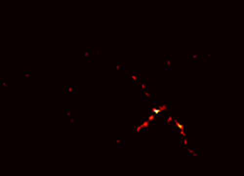

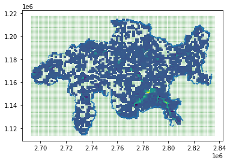

```python
# Loading the fresh contributors per cell, removing urban areas
flickr_points_num_urban = flickr_points_num
for i in urban_poly_list:
    urban_raster = borderRaster(raster_coords, 1000, i)
    flickr_points_num_urban = urban_raster.remove_outside(flickr_points_num_urban, position=1)

for i in range(len(flickr_points_num_urban)):
    if flickr_points_num_urban[i] == 0:
        flickr_points_num_urban[i] = None

flickr_points_reshaped_urban = flickr_filtered_index.reshapeList(flickr_points_num_urban)

# Calculating the global Morans I after filtering
morans_filtered = MoranI(flickr_points_reshaped_urban)
print(f'The global Morans I after removal of urban areas for 1km resolution is {morans_filtered.globalMoranI():.4f}')
print(f'The expected value after removal of urban areas for 1km resolution is {morans_filtered.expectedValue():.4f}')

# And the local one
local_filtered = morans_filtered.localMoranI()

# Preparing for Hotspot image
local_filtered_prepped = []
for i in range(len(local_filtered)):
    if local_filtered[i] != None:
        local_filtered_prepped.append(local_filtered[i]-min(x for x in local_filtered if x is not None))
    else:
        local_filtered_prepped.append(None)

# Hotspot image
display(points_to_im(local_filtered_prepped)[1])


# Using data for second visualisation
log_data = points_to_im(local_filtered_prepped)[0]
log_data = log_data.tolist()

flat_list = []
for xs in log_data:
    for x in xs:
        flat_list.append(x)

log_flat = []
for i in range(len(flat_list)):
    if flat_list[i] == 0:
        log_flat.append(None)
    else:
        log_flat.append(flat_list[i]-(min(flat_list)))

# Result
plt.scatter(raster_x, raster_y, s=1, color='green', alpha=0.2)
plt.scatter(contri_raster_x, contri_raster_y, s=10, marker = "s", c = log_flat, cmap='viridis')
plt.scatter(border_poly_x, border_poly_y, s=0.5)
plt.show()
```

# 5.3 Morans I before removal of urban areas, 2x2 km grid resolution

New Index calculations, new calculation times. Less because of the resolution but still ~10 min

```python
# First we need to run the index again for 2km resolution

# Getting spatial index of flickr data
bbox_border_new = Bbox(flickr_filtered['points'])
flickr_filtered_index = PointIndex(flickr_filtered['points'], flickr_filtered['user'], bbox_border_new, 2000)

# Getting the number of contributors per raster
flickr_points_num = flickr_filtered_index.points_num

# Getting centroid coordinates of rasters
raster_coords = flickr_filtered_index.raster_coords

# Rasterizing border
border_raster = borderRaster(raster_coords, 2000, border_poly)

# Removing outside index cells
flickr_points_num = border_raster.remove_outside(flickr_points_num, position=None)
flickr_points_reshaped = flickr_filtered_index.reshapeList(flickr_points_num)
```

```
The global Morans I before removal of urban area for 2km resolution is 0.1157
The expected value before removal of urban area for 2km resolution is -0.0007
```

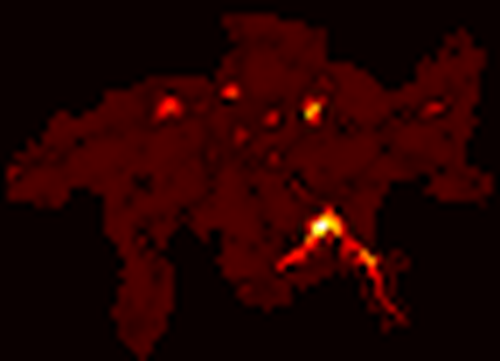

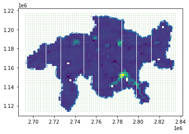

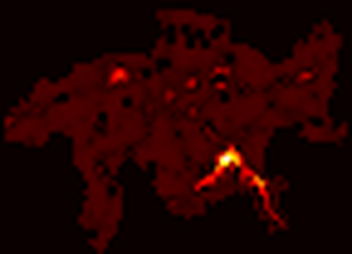

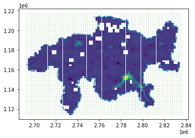

```python
# Global Morans I & Expected Value
morans_prefiltered = MoranI(flickr_points_reshaped)
print(f'The global Morans I before removal of urban area for 2km resolution is {morans_prefiltered.globalMoranI():.4f}')
print(f'The expected value before removal of urban area for 2km resolution is {morans_prefiltered.expectedValue():.4f}')

# Saving values for comparing results in the end
global_2km_without = morans_prefiltered.globalMoranI()
exp_2km_without = morans_prefiltered.expectedValue()

# Local Morans I
local_2km_without = morans_prefiltered.localMoranI()

# Prepararing the data for visualization
local_prepped = []
for i in range(len(local_2km_without)):
    if local_2km_without[i] != None:
        local_prepped.append(local_2km_without[i]-min(x for x in local_2km_without if x is not None))
    else:
        local_prepped.append(None)

# Display in a Heatmap Image
display(points_to_im(local_prepped)[1])

# Using the logarithmised data from the points to image function for different visualisation
log_data = points_to_im(local_prepped)[0]

# More preperation for visualiations
log_data = log_data.tolist()
flat_list = []
for xs in log_data:
    for x in xs:
        flat_list.append(x)
log_flat = []
for i in range(len(flat_list)):
    if flat_list[i] == 0:
        log_flat.append(None)
    else:
        log_flat.append(flat_list[i]-(min(flat_list)))

# Preparing plot
border_poly_x = list(map(lambda i: i.x, border_poly))
border_poly_y = list(map(lambda i: i.y, border_poly))

contri_raster_x = list(map(lambda i: i.x, raster_coords))
contri_raster_y = list(map(lambda i: i.y, raster_coords))

# Plotting
plt.scatter(contri_raster_x, contri_raster_y, s=1, color='green', alpha=0.2)
plt.scatter(contri_raster_x, contri_raster_y, s=10, marker = "s", c = log_flat, cmap='viridis')
plt.scatter(border_poly_x, border_poly_y, s=0.5)
plt.show()

# Now removing the urban areas
urban_removed = local_2km_without
for i in urban_poly_list:
    urban_raster = borderRaster(raster_coords, 2000, i)
    urban_removed = urban_raster.remove_outside(urban_removed, position=1)

urban_prepped = []
for i in range(len(urban_removed)):
    if urban_removed[i] != None:
        urban_prepped.append(urban_removed[i]-min(x for x in urban_removed if x is not None))
    else:
        urban_prepped.append(None)



# Heatmap image with urban areas removed
display(points_to_im(urban_prepped)[1])

# Same as above, preparation and alternative plotting
log_data = points_to_im(urban_prepped)[0]
log_data = log_data.tolist()

flat_list = []
for xs in log_data:
    for x in xs:
        flat_list.append(x)

log_flat = []
for i in range(len(flat_list)):
    if flat_list[i] == 0:
        log_flat.append(None)
    else:
        log_flat.append(flat_list[i]-(min(flat_list)))


plt.scatter(contri_raster_x, contri_raster_y, s=1, color='green', alpha=0.2)
plt.scatter(contri_raster_x, contri_raster_y, s=10, marker = "s", c = log_flat, cmap='viridis')
plt.scatter(border_poly_x, border_poly_y, s=0.5)
plt.show()
```

# 5.4 Morans I after removal of urban areas, 2x2 km grid resolution

```
The global Morans I after removal of urban areas for 2km resolution is 0.1053
The expected value after removal of urban areas for 2km resolution is -0.0007
```

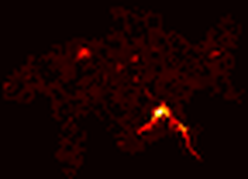

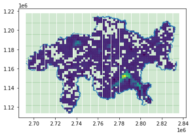

```python
# Loading the fresh contributors per cell, removing urban areas
flickr_points_num_urban = flickr_points_num
for i in urban_poly_list:
    urban_raster = borderRaster(raster_coords, 2000, i)
    flickr_points_num_urban = urban_raster.remove_outside(flickr_points_num_urban, position=1)

for i in range(len(flickr_points_num_urban)):
    if flickr_points_num_urban[i] == 0:
        flickr_points_num_urban[i] = None

flickr_points_reshaped_urban = flickr_filtered_index.reshapeList(flickr_points_num_urban)

# Calculating the global Morans I after filtering
morans_filtered = MoranI(flickr_points_reshaped_urban)
print(f'The global Morans I after removal of urban areas for 2km resolution is {morans_filtered.globalMoranI():.4f}')
print(f'The expected value after removal of urban areas for 2km resolution is {morans_filtered.expectedValue():.4f}')

# And the local one
local_filtered = morans_filtered.localMoranI()

# Preparing for Hotspot image
local_filtered_prepped = []
for i in range(len(local_filtered)):
    if local_filtered[i] != None:
        local_filtered_prepped.append(local_filtered[i]-min(x for x in local_filtered if x is not None))
    else:
        local_filtered_prepped.append(None)

# Hotspot image
display(points_to_im(local_filtered_prepped)[1])


# Using data for second visualisation
log_data = points_to_im(local_filtered_prepped)[0]
log_data = log_data.tolist()

flat_list = []
for xs in log_data:
    for x in xs:
        flat_list.append(x)

log_flat = []
for i in range(len(flat_list)):
    if flat_list[i] == 0:
        log_flat.append(None)
    else:
        log_flat.append(flat_list[i]-(min(flat_list)))

# Result
plt.scatter(raster_x, raster_y, s=1, color='green', alpha=0.2)
plt.scatter(contri_raster_x, contri_raster_y, s=10, marker = "s", c = log_flat, cmap='viridis')
plt.scatter(border_poly_x, border_poly_y, s=0.5)
plt.show()
```